# KBO STATS

Nancy Kwak

2024-11-09

# 1. INTRODUCTION

- Before we start, make sure to have the “KBOstats2024.csv” file downloaded to reproduce this project! (accessible in github repository)
- repository link for your reference: https://github.com/nancy1404/project2.git

## a. DATASET INFORMATION / SOURCES

- **WHAT’S THE CONTEXT OF THIS DATASET?**

> My topic is the hitter statistics retrieved from 2024 Korean Baseball Organization (KBO) League (regular season only), where it evaluates each player’s performance throughout the season. All the information are directly collected from the KBO League and include various performance metrics that are frequently updated for accuracy. All the stats collected through this specific site is specifically for international KBO fans since the official KBO Data Center only collects and provide data in Korean to public.
- **HYPERLINK / PICTURE**
  - Here is a hyperlink to the general mykbostats.com website
  - [Here is the specific data page I used for this project](https://mykbostats.com/stats/top/ops?pa_cutoff=223)

[figure not shown]

*Logos of each teams currently in KBO League / [image found here](https://i.ytimg.com/vi/yUhf8wjp5gc/maxresdefault.jpg)

- **WHY DID I PICK THIS DATASET?**
  - I chose this dataset because I grew up loving Korean Baseball (thanks to my dad) and my interest in baseball and sports analytics led me to decide to major in SDS at UT. On top o fthat, since we have done a short analysis using data with MLB statistics, I thought it would be interesting to see how KBO League Statistics look like.
- **WHAT AM I INVESTIGATING?**
  - I decided to separate this project into three major parts. First, I want to investigate the overall trend that all KBO league players had for the 2024 season. So I will demonstrate how the variables such as OPS, BA, HR, and BB are distributed for all qualified players. Secondly, I want to investigate the relationship between these variables. So I will demonstrate OPS vs. SLG, BA vs. OBP, HR vs. PA, and SLG vs. AB. Finally, I want to see if the final rank of the team is due to that specific team’s overall higher average of these variables (OPS, BA, HR, BB) among the players in that team.

# 2. DATA PREPARATING

# 3. VARIABLE DESCRIPTION

## a. CLEANED DATASET

- Here’s how the final version of “final.KBOstats” looks like:

head(final.KBOstats)

| Player | Team | OPS | BA | OBP | SLG | HR | BB | AB | PA |
| --- | --- | --- | --- | --- | --- | --- | --- | --- | --- |
| Kim Do-yeong | Kia Tigers | 1.067 | 0.347 | 0.420 | 0.647 | 38 | 66 | 544 | 625 |
| Koo Ja-wook | Samsung Lions | 1.044 | 0.343 | 0.417 | 0.627 | 33 | 55 | 493 | 568 |
| Matthew Davidson | NC Dinos | 1.003 | 0.306 | 0.370 | 0.633 | 46 | 39 | 504 | 567 |
| Mel Rojas Jr. | KT Wiz | 0.989 | 0.329 | 0.421 | 0.568 | 32 | 88 | 572 | 670 |
| Choi Jeong | SSG Landers | 0.978 | 0.291 | 0.384 | 0.594 | 37 | 55 | 468 | 550 |
| Austin Dean | LG Twins | 0.957 | 0.319 | 0.384 | 0.573 | 32 | 61 | 527 | 604 |

## b. VARIABLES OF INTEREST

  | Variable | Type | Description |
  | --- | --- | --- |
  | Player | Categorical | The name of the baseball player. |
  | Team | Categorical | The name of the team the player belongs to. |
  | OPS | Numeric | On-Base Plus Slugging; a combined measure of a player’s ability to get on base and hit for power |
  | BA | Numeric | Batting Average; the ratio of a player’s hits to their total *at-bats (AB). |
  | OBP | Numeric | On-base Percentage; measures how often a player reaches bases (via hits, walks, or hit by pitch). |
  | SLG | Numeric | Slugging Percentage; a measure of the power of a hitter, calculated as total bases divided by *at-bats. |
  | HR | Numeric | Home Runs; the total number of home runs hit by the player. |
  | BB | Numeric | Walks; the number of times the player reached base via a base on balls. |
  | AB | Numeric | At-Bats; the total number of official at-bats the player has had. |
  | PA | Numeric | Plate Appearances; the total number of times the player appeared at the plate, including all outcomes (hits, walks, etc.). |

# 4. UNIVARIATE ANALYSES (4 variables)

- For the univariate analyses, I chose “OPS”, “BA”, “HR”, and “BB”.
- Here, I am first going to see the trend of each chosen variables for the whole league for each players.

## a. OPS (On-base Plus Slugging) - graph 4a

> OPS = OBP (On-base Percentage) + SLG (Slugging Percentage)

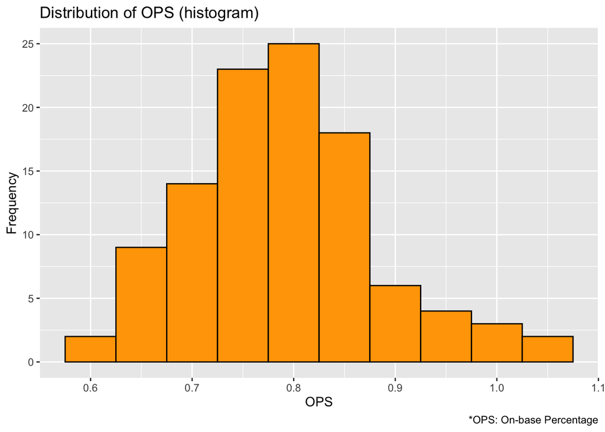

Descriptive Statistics for OPS

| Mean | Median | Minimum | Maximum | Standard_Deviation |
| --- | --- | --- | --- | --- |
| 0.79 | 0.788 | 0.578 | 1.067 | 0.091 |

### Graph 4A Brief Description

- First things first, the spread of OPS, indicated by the standard deviation, demonstrates the variability among player performance. The histogram for OPS shows that the data is slightly skewed right, which means only a few players have exceptionally high OPS scores. The OPS values are clustered around the mean value which is 0.79, with a central tendency that we can quantify using the mean and median.
- The mean and median help to understand the typical OPS, while the standard deviation provides the insight into the overall spread.

#### BEST & WORST OPS!

Best OPS

| Player | Team | OPS | BA | OBP | SLG | HR | BB | AB | PA |
| --- | --- | --- | --- | --- | --- | --- | --- | --- | --- |
| Kim Do-yeong | Kia Tigers | 1.067 | 0.347 | 0.420 | 0.647 | 38 | 66 | 544 | 625 |
| Koo Ja-wook | Samsung Lions | 1.044 | 0.343 | 0.417 | 0.627 | 33 | 55 | 493 | 568 |
| Matthew Davidson | NC Dinos | 1.003 | 0.306 | 0.370 | 0.633 | 46 | 39 | 504 | 567 |

Worst OPS

| Player | Team | OPS | BA | OBP | SLG | HR | BB | AB | PA |
| --- | --- | --- | --- | --- | --- | --- | --- | --- | --- |
| Kim Jae-hyun | Kiwoom Heroes | 0.578 | 0.243 | 0.297 | 0.281 | 0 | 14 | 288 | 326 |
| Jeon Min-jae | Doosan Bears | 0.599 | 0.246 | 0.301 | 0.298 | 2 | 17 | 248 | 276 |
| Jo Soo-haeng | Doosan Bears | 0.627 | 0.265 | 0.334 | 0.293 | 0 | 33 | 328 | 382 |

- Above, I reported 3 players with best OPS values, and 3 players with worst OPS values.
- For the three players who had the highest OPS values, the average was 1.038 and for the three players who had the lowest OPS values, the average was 0.601. The difference was 0.437, which was significant amount of difference in baseball field.

## b. BA (Batting Average) - graph 4b

> BA = Player’s Hits / Total AB

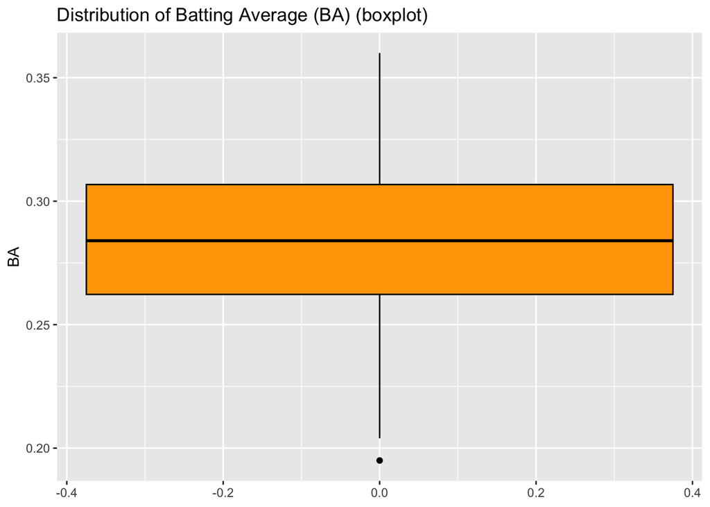

Descriptive Statistics for Batting Average (BA)

| Median | IQR | Variance |
| --- | --- | --- |
| 0.284 | 0.0445 | 0.00098 |

### Graph 4B Brief Description

- First things first, the box plot of BA demonstrates the central tendency and spread of the data. The median was 0.28, which means the typical player has a bating average around this value, where the most players have a slightly below-average batting performance.
- The middle 50% of players’ BA values are falling within an IQR (interquartile range) of 0.0445, which suggests that the batting averages are relatively consistent among players.
- Finally, the variance of 9.8^{-4} which indicates that most players’ BA value are closely grouped around the median with pretty low overall variability.

#### BEST & WORST BA!

Best BA

| Player | Team | OPS | BA | OBP | SLG | HR | BB | AB | PA |
| --- | --- | --- | --- | --- | --- | --- | --- | --- | --- |
| Guillermo Heredia | SSG Landers | 0.937 | 0.360 | 0.399 | 0.538 | 21 | 28 | 541 | 591 |
| Kim Min-hyuck | KT Wiz | 0.829 | 0.353 | 0.410 | 0.419 | 1 | 35 | 351 | 393 |
| Víctor Reyes | Lotte Giants | 0.904 | 0.352 | 0.394 | 0.510 | 15 | 46 | 574 | 632 |

Worst BA

| Player | Team | OPS | BA | OBP | SLG | HR | BB | AB | PA |
| --- | --- | --- | --- | --- | --- | --- | --- | --- | --- |
| Kim Hyung-jun | NC Dinos | 0.658 | 0.195 | 0.285 | 0.373 | 17 | 45 | 354 | 414 |
| Kim Seong-uk | NC Dinos | 0.671 | 0.204 | 0.291 | 0.380 | 17 | 31 | 358 | 412 |
| Park Byung-ho | Samsung Lions | 0.782 | 0.231 | 0.333 | 0.449 | 23 | 47 | 350 | 406 |

## c. HR (Home Runs). - graph 4c

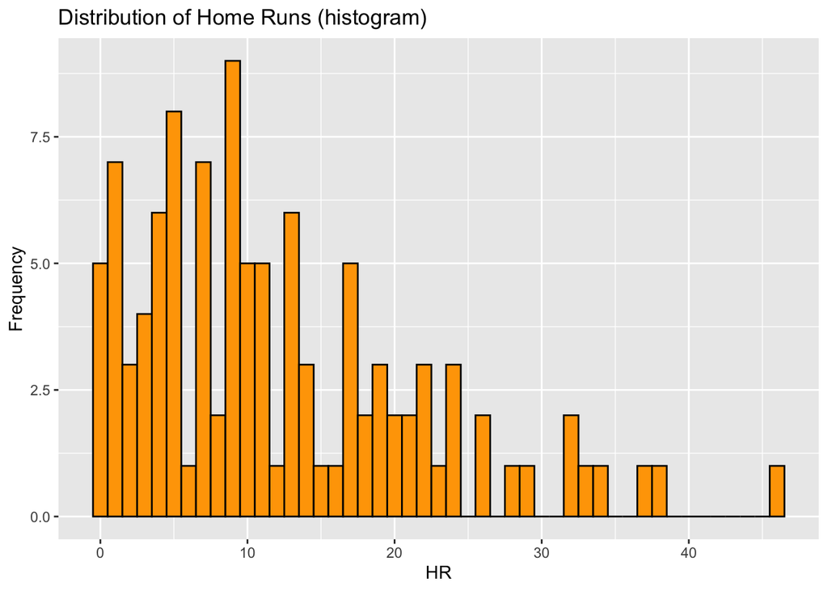

Descriptive Statistics for Home Runs (HR)

| Mean | Standard_Deviation | Minimum | Maximum | Range |
| --- | --- | --- | --- | --- |
| 12.18 | 9.74 | 0 | 46 | 46 |

### Graph 4C Brief Description

- First things first, looking at the histogram, HR data is clearly right skewed, with most players hitting fewer home runs and only a few reaching high totals.
- The mean of HR was 12.18, suggesting that on average players in this league hit slightly more than 12 home runs, but the standard deviation of 9.74 indicates lots of variability in home run counts.
- The range was 46 which emphasizes the extreme variation, with some players hitting 0 home runs while others hitting 46.

#### BEST & WORST HR!

Best HR

| Player | Team | OPS | BA | OBP | SLG | HR | BB | AB | PA |
| --- | --- | --- | --- | --- | --- | --- | --- | --- | --- |
| Matthew Davidson | NC Dinos | 1.003 | 0.306 | 0.370 | 0.633 | 46 | 39 | 504 | 567 |
| Kim Do-yeong | Kia Tigers | 1.067 | 0.347 | 0.420 | 0.647 | 38 | 66 | 544 | 625 |
| Choi Jeong | SSG Landers | 0.978 | 0.291 | 0.384 | 0.594 | 37 | 55 | 468 | 550 |

Worst HR

| Player | Team | OPS | BA | OBP | SLG | HR | BB | AB | PA |
| --- | --- | --- | --- | --- | --- | --- | --- | --- | --- |
| Moon Sung-ju | LG Twins | 0.791 | 0.315 | 0.411 | 0.380 | 0 | 49 | 305 | 361 |
| Shin Min-jae | LG Twins | 0.758 | 0.297 | 0.401 | 0.357 | 0 | 64 | 387 | 474 |
| Ko Young-woo | Kiwoom Heroes | 0.648 | 0.256 | 0.329 | 0.319 | 0 | 28 | 254 | 290 |

- Above, I reported 3 players with best HR values, and 3 players with worst HR values.
- For the three players who had the highest HR values, the average was 40.33 and for the three players who had the lowest HR values, the average was 0. The difference was 40.33, which was significant amount of difference in baseball field.

## d. BB (Walks) - graph 4d

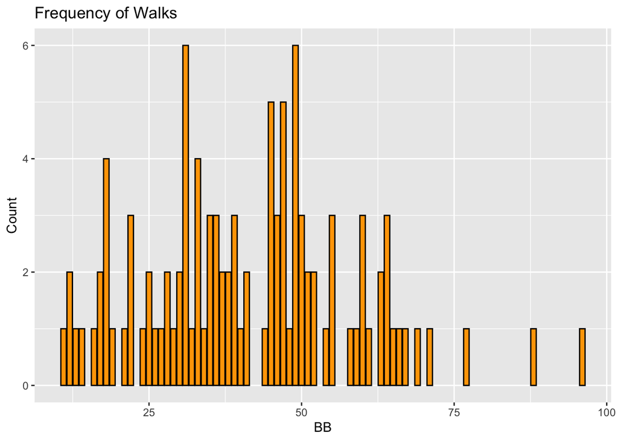

Descriptive Statistics for Walks (BB)

| Mean | Median | Standard_Deviation |
| --- | --- | --- |
| 41.34 | 40.5 | 16.93 |

### Graph 4D Brief Description

- The mean of BB was 41.34 and the median of BB was 40.5 which was quite close, suggesting threre are no extreme skew, showing relatively symmetric distribution.
- The standard deviation was 16.93 which indicates moderate variability, showing that while most players’ walk counts are around average, there are some considerably higher or lower counts in the league. This trend demonstrates a range of patience at the plate, where the notably high numbers of walks might be due to a keen eye for pitches or strategic batting approaches.

#### BEST & WORST BB!

Best BB

| Player | Team | OPS | BA | OBP | SLG | HR | BB | AB | PA |
| --- | --- | --- | --- | --- | --- | --- | --- | --- | --- |
| Hong Chang-ki | LG Twins | 0.857 | 0.336 | 0.447 | 0.410 | 5 | 96 | 524 | 637 |
| Mel Rojas Jr. | KT Wiz | 0.989 | 0.329 | 0.421 | 0.568 | 32 | 88 | 572 | 670 |
| Kwon Hui-dong | NC Dinos | 0.869 | 0.300 | 0.417 | 0.452 | 13 | 77 | 416 | 511 |

Worst BB

| Player | Team | OPS | BA | OBP | SLG | HR | BB | AB | PA |
| --- | --- | --- | --- | --- | --- | --- | --- | --- | --- |
| Byeon Sang-kwon | Kiwoom Heroes | 0.631 | 0.251 | 0.289 | 0.342 | 5 | 11 | 219 | 232 |
| Kim Tae-gun | Kia Tigers | 0.711 | 0.264 | 0.328 | 0.383 | 7 | 12 | 235 | 270 |
| Park Ji-hwan | SSG Landers | 0.703 | 0.276 | 0.317 | 0.386 | 4 | 12 | 228 | 249 |

# 5A. BIVARIATE ANALYSES

> For the bivariate analyses, I chose “OPS vs. SLG”, “BA vs. OBP”, “HR vs. PA” and “SLG vs. AB”. Through these analyses, we will be able to see if there are actually relationships between each variables and how they are related.

## a. OPS vs. SLG - graph 5a

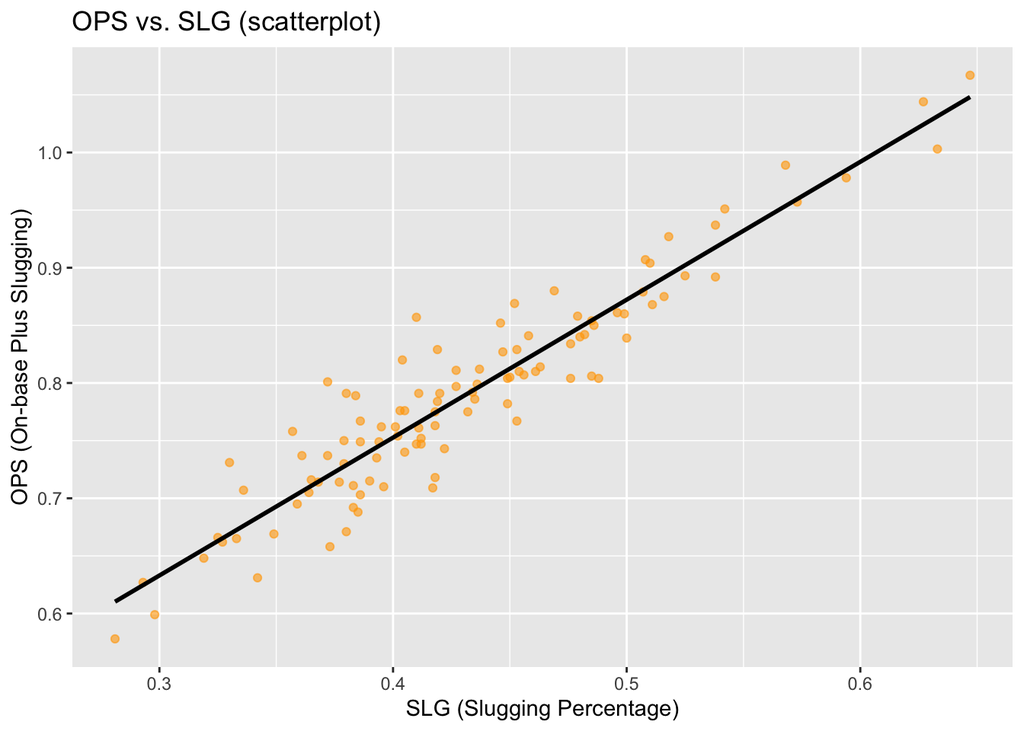

Correlation Coefficient for OPS vs. SLG

| x |
| --- |
| 0.94 |

### Graph 5a Brief Description

- A correlation coefficient was 0.94 which indicates a very strong positive linear relationship between OPS and SLG. This type of relationship suggests that as SLG increases, OPS also increases, demonstrating that players who excel in power hitting generally have higher overall offensive performance.
- The scatter plot also shows this relationship clearly with points mostly following the linear regression line.

## b. BA vs. OBP - graph 5b

```
## # A tibble: 6 × 3
##   Player           Team          `On-base Effectiveness`
##   <chr>            <chr>                           <dbl>
## 1 Kim Do-yeong     Kia Tigers                       1.21
## 2 Koo Ja-wook      Samsung Lions                    1.22
## 3 Matthew Davidson NC Dinos                         1.21
## 4 Mel Rojas Jr.    KT Wiz                           1.28
## 5 Choi Jeong       SSG Landers                      1.32
## 6 Austin Dean      LG Twins                         1.20
```

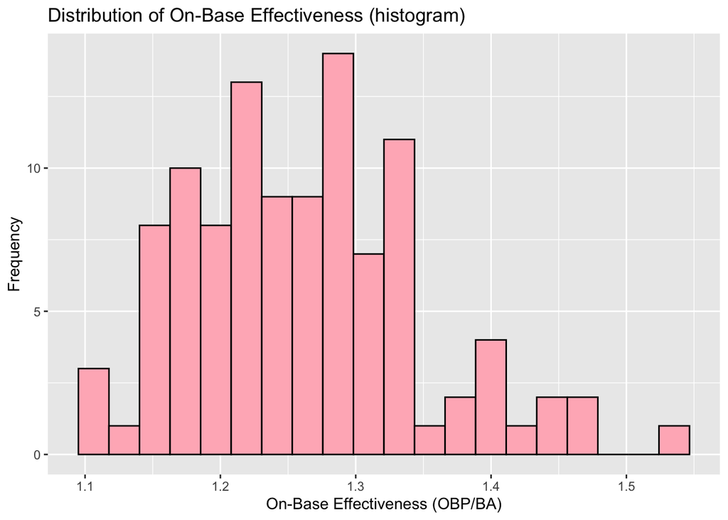

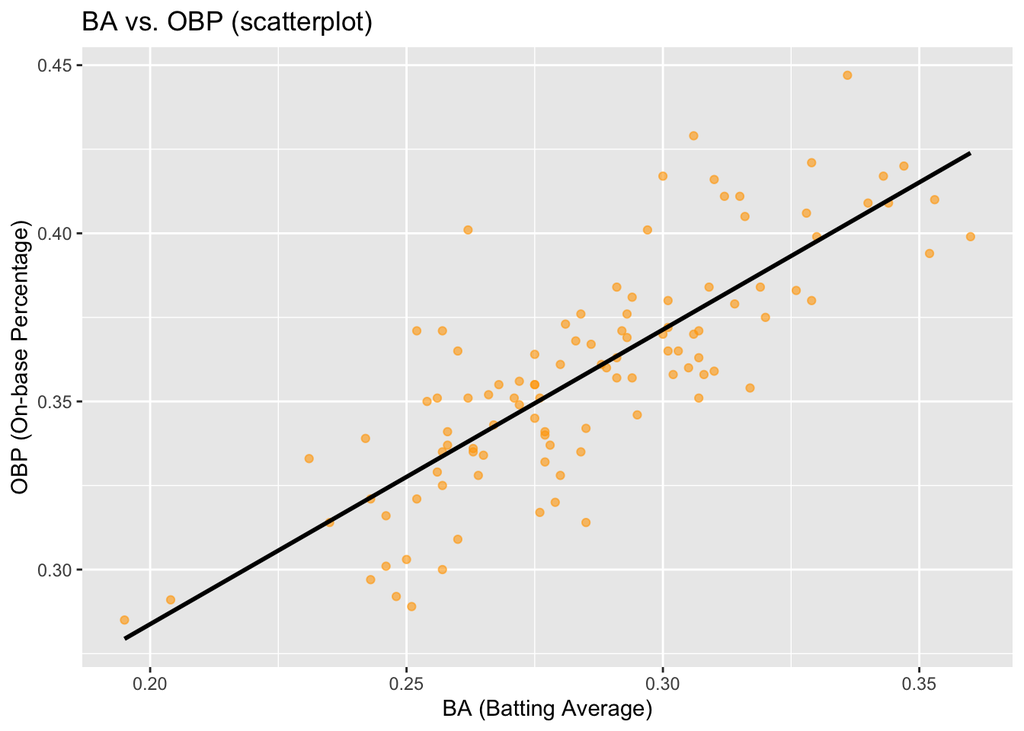

Correlation Coefficient for BA vs. OBP

| x |
| --- |
| 0.805 |

### Graph 5b Brief Description

- First, I made a new variable called “on-base effectiveness” which is calculated by OBP divided by BA. The on-base effectiveness histogram shows that the distribution is slightly right-skewed, clustering primarily between 1.2 and 1.3, suggesting that most players’ on-base abilities exceed their pure hitting abilities, probably due to walks or other strategies.
- Secondly, the scatter plot for BA vs. OBP shows a strong positive linear relationship, wich a correlation coefficient of 0.805, demonstrating that players with higher batting averages tend to have higher on-base percentages.
- Combined together, these graphs show that while BA and OBP are closely related, some players have exceptional on-base effectiveness beyond what their BA alone showcases. This stats especially shows the possible impact of non-hit contributions, including walks or other individual strategies.

## c. HR vs. PA - graph 5c

```
## # A tibble: 6 × 3
##   Player           Team          `Power Ratio`
##   <chr>            <chr>                 <dbl>
## 1 Kim Do-yeong     Kia Tigers            0.061
## 2 Koo Ja-wook      Samsung Lions         0.058
## 3 Matthew Davidson NC Dinos              0.081
## 4 Mel Rojas Jr.    KT Wiz                0.048
## 5 Choi Jeong       SSG Landers           0.067
## 6 Austin Dean      LG Twins              0.053
```

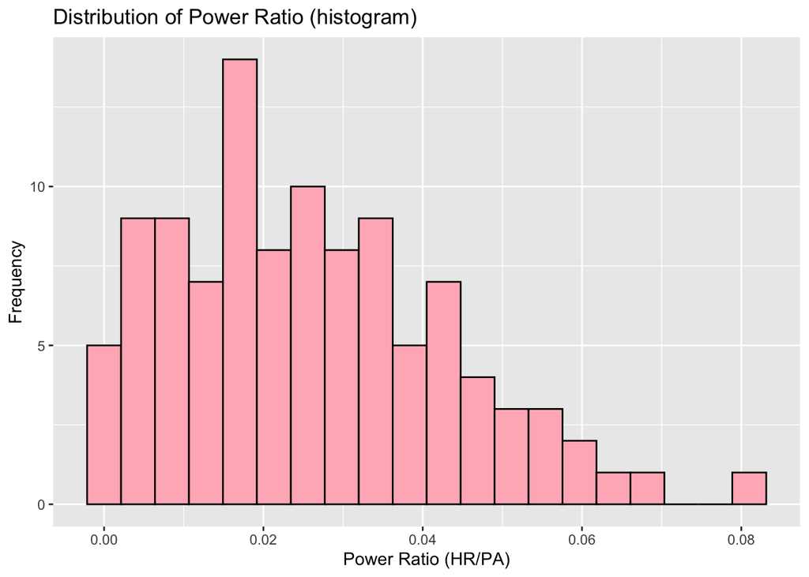

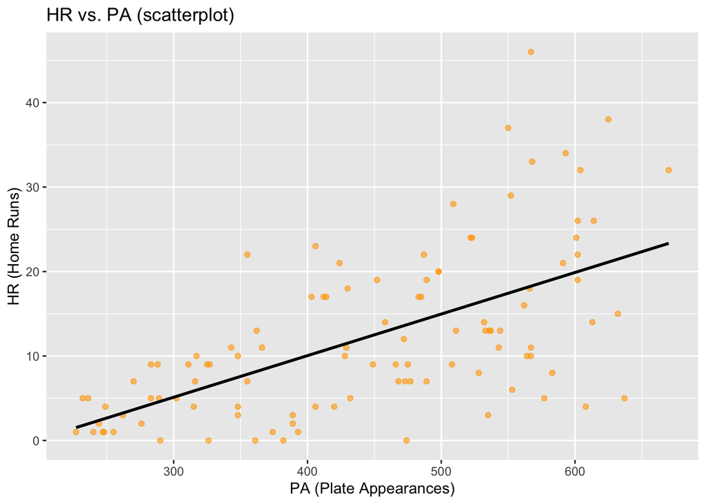

Correlation Coefficient for PA vs. HR

| x |
| --- |
| 0.606 |

### Graph 5c Brief Description

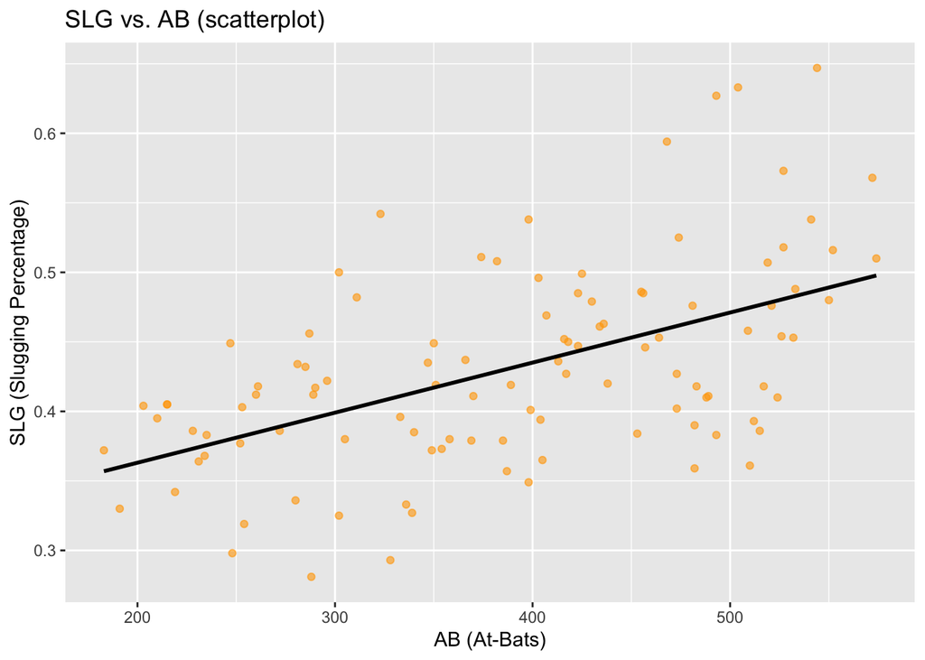

Correlation Coefficient for SLG vs. AB

| x |
| --- |
| 0.53 |

### Graph 5d Brief Description

- The scatter plot for SLG vs. AB shows a moderately linear relationship, with the correlation coefficient of 0.53, suggesting there’s a somewhat positive relationship between AB and SLG. This stats show that the players with more at-bats tend to have higher slugging percetages, though we cannot say with 100% confidence since the relationship isn’t strong enough to make a certain conclusion.
- However, the moderate correlation iplies that while opportunity (more at-bats) may contribute to higher SLG, other factors including individual strategies or power hitting skil also could play an important role.

# 5B. MULTIVARAITE ANALYSIS

> I chose to look through 3 variables, OPS, BA, and HR, and make multivariate scatter plot. Here, I first reshaped HR into 3 categories: low, medium, and high (depending on which quartile each belongs to). I put sample examples as well.

```
## # A tibble: 6 × 4
##   Player        Team             HR `HR Category`
##   <chr>         <chr>         <dbl> <chr>
## 1 Kim Sang-su   KT Wiz            4 Low
## 2 Yang Eui-ji   Doosan Bears     17 High
## 3 Jang Jin-hyuk Hanwha Eagles     9 Medium
## 4 Lee Yu-chan   Doosan Bears      3 Low
## 5 Lee Chang-jin Kia Tigers        1 Low
## 6 Ronnie Dawson Kiwoom Heroes    11 Medium
```

> Now, I used that HR Category for the size of the bubbles in the multivariate scatter plot, where the size of each bubble represents whether the player falls into the “Low”, “Medium”, or “High” HR Category.

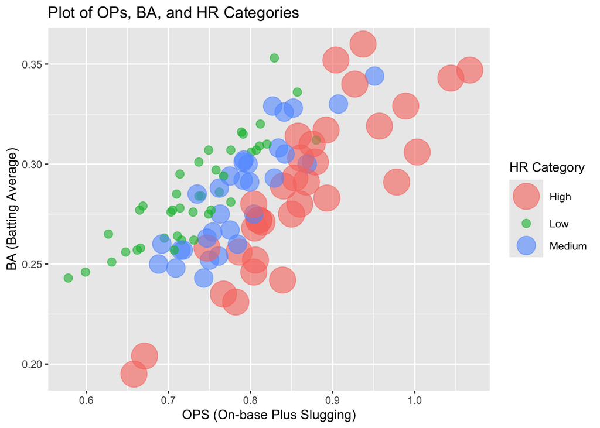

# 5C. TEAM ANALYSIS

> First, here’s the KBO League 2024 Standing for all 10 teams.

2024 KBO League Ranking

| Rank | Team |
| --- | --- |
| 1 | Kia Tigers |
| 2 | Samsung Lions |
| 3 | LG Twins |
| 4 | Doosan Bears |
| 5 | KT Wiz |
| 6 | SSG Landers |
| 7 | Lotte Giants |
| 8 | Hanwha Eagles |
| 9 | NC Dinos |
| 10 | Kiwoom Heroes |

> Now, merge this data to the “final.KBOstats” dataset so that we can compare against teams. Then I created a ggplot to see if the average performance for each team actually affects the final “Rank” for each team.

Average Data for Each Team

| Team | Rank | OPS | BA | HR | OBP |
| --- | --- | --- | --- | --- | --- |
| Kia Tigers | 1 | 0.822 | 0.299 | 12.9 | 0.372 |
| Samsung Lions | 2 | 0.813 | 0.280 | 15.8 | 0.362 |
| LG Twins | 3 | 0.794 | 0.291 | 10.5 | 0.374 |
| Doosan Bears | 4 | 0.763 | 0.281 | 11.7 | 0.348 |
| KT Wiz | 5 | 0.788 | 0.284 | 13.1 | 0.358 |
| SSG Landers | 6 | 0.780 | 0.282 | 12.3 | 0.346 |
| Lotte Giants | 7 | 0.833 | 0.303 | 11.7 | 0.370 |
| Hanwha Eagles | 8 | 0.767 | 0.279 | 10.6 | 0.356 |
| NC Dinos | 9 | 0.790 | 0.276 | 14.6 | 0.352 |
| Kiwoom Heroes | 10 | 0.752 | 0.283 | 8.2 | 0.351 |

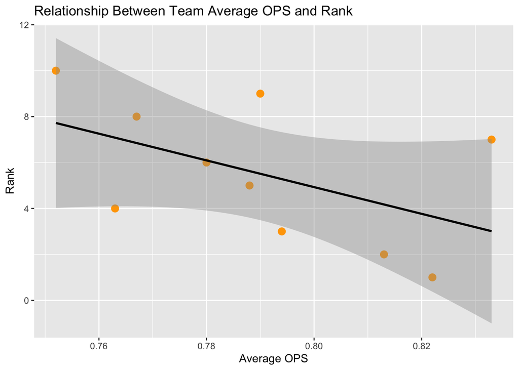

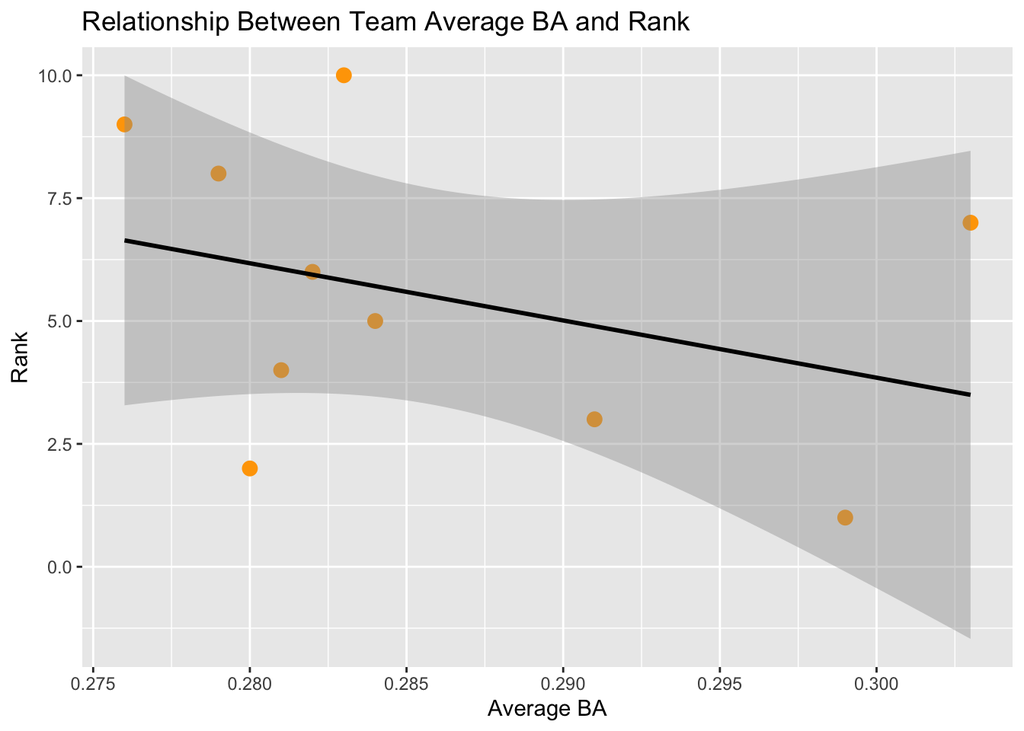

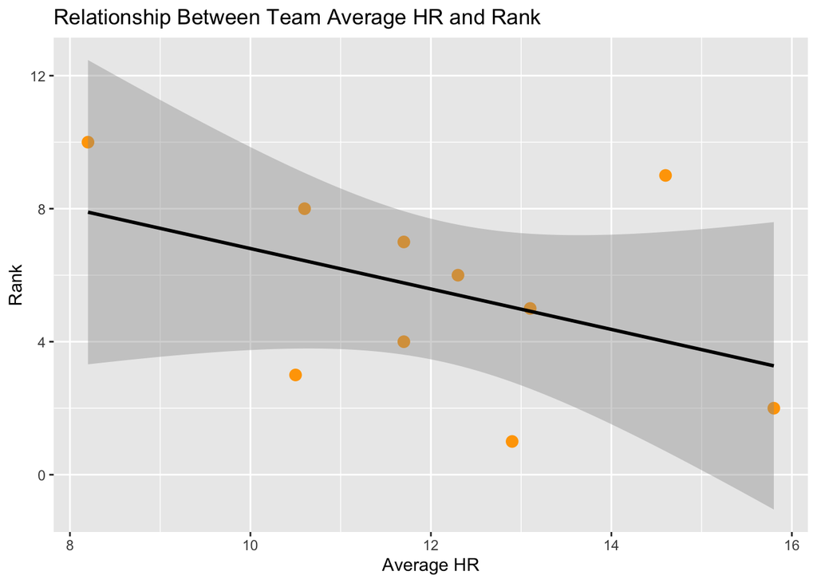

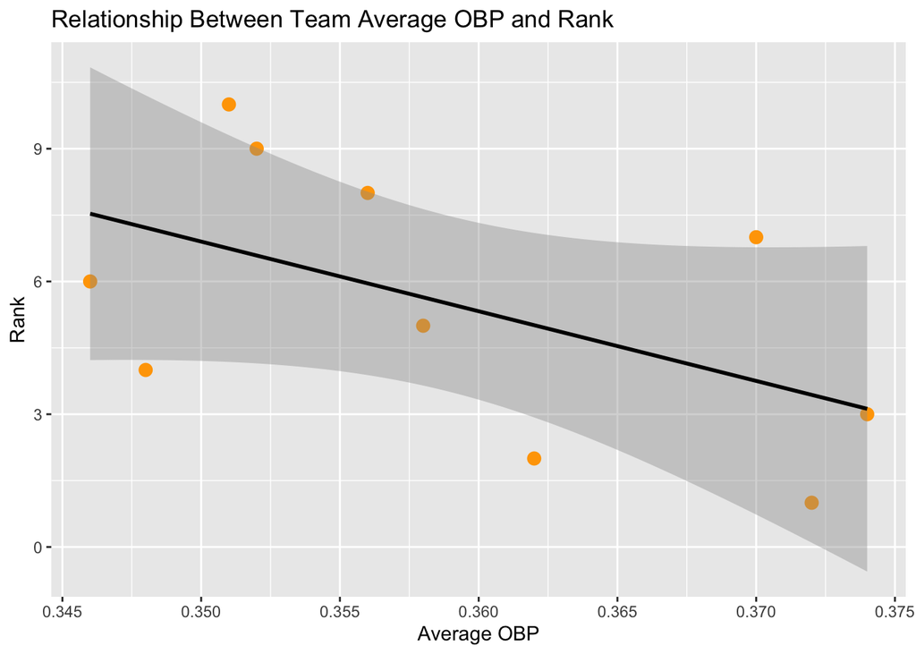

Correlation Coefficient for Rank vs. OPS

| x |
| --- |
| -0.505197 |

Correlation Coefficient for Rank vs. BA

| x |
| --- |
| -0.3442739 |

Correlation Coefficient for Rank vs. HR

| x |
| --- |
| -0.4334892 |

Correlation Coefficient for Rank vs. OBP

| x |
| --- |
| -0.5305404 |